# SDS 291 - STAT2 R Companion Chapter 4

#### randomization test for the correlation

generate a randomized test for the correlation between the two variables.

| p_value |
| --- |
| 0.262 |

visualise the correlation values

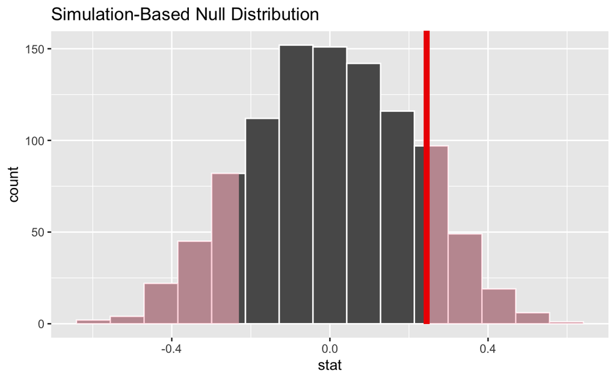

#### inference in multiple regression

- adapt your formula from the `specify()` function to instead follow the formula of the multiple regression model.
- the pipe gets the `fit()` instead of `calculate()`

| term | p_value |
| --- | --- |
| MathSAT | 0.538 |
| VerbalSAT | 0.770 |
| VerbalSAT:MathSAT | 0.580 |
| intercept | 0.756 |

visualize the model values

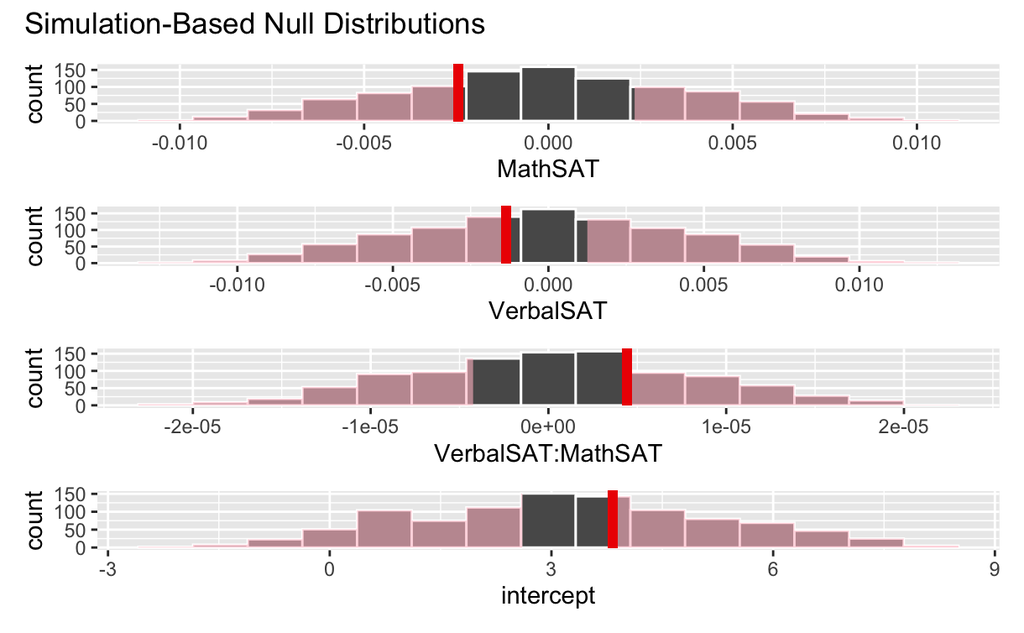

#### controlling randomness

3 permutations of the correlation values –> notice how the first and second versions have different correlation values

```
Response: GPA (numeric)
Explanatory: VerbalSAT (numeric)
Null Hypothesis: independence
```

| replicate | stat |
| --- | --- |
| 1 | -0.147882193 |
| 2 | 0.042317425 |
| 3 | 0.004914153 |

```
Response: GPA (numeric)
Explanatory: VerbalSAT (numeric)
Null Hypothesis: independence
```

| replicate | stat |
| --- | --- |
| 1 | 0.3116210 |
| 2 | -0.2889005 |
| 3 | 0.1954321 |

setting the seed will prevent different random values when you run the same permutations

```r
set.seed(11)
SATGPA %>%
  specify(GPA ~ VerbalSAT) %>%
  hypothesise(null = "independence") %>%
  generate(reps = 3, type = "permute") %>%
  calculate(stat = "correlation")
```

```
Response: GPA (numeric)
Explanatory: VerbalSAT (numeric)
Null Hypothesis: independence
```

| replicate | stat |
| --- | --- |
| 1 | 0.183335720 |
| 2 | 0.008415736 |
| 3 | -0.117482086 |

```r
set.seed(11)
SATGPA %>%
  specify(GPA ~ VerbalSAT) %>%
  hypothesise(null = "independence") %>%
  generate(reps = 3, type = "permute") %>%
  calculate(stat = "correlation")
```

```
Response: GPA (numeric)
Explanatory: VerbalSAT (numeric)
Null Hypothesis: independence
```

| replicate | stat |
| --- | --- |
| 1 | 0.183335720 |
| 2 | 0.008415736 |
| 3 | -0.117482086 |